# Phần 3 — Lập lịch phân công

Hai bài lớn nhất của báo cáo, và là nơi hai luận điểm phương pháp lộ rõ nhất.

**Bài 3.1** là chỗ gặp cái bẫy nguy hiểm nhất trong cả dự án: hai mẫu chính thức của IBM cùng mang tên *sports scheduling* nhưng là **hai bài toán khác nhau** — bản OPL là double round-robin có sân nhà/khách và tối thiểu số break, bản docplex là lịch NFL hai bảng đấu, **không có khái niệm home/away nên không có break**. Xếp số liệu hai bản này cạnh nhau là so hai thứ khác nhau mà nhìn bảng không thấy được. Cách xử lý: giữ nguyên cả hai mẫu chính thức, và viết thêm một bản port biến thể A sang `docplex.cp` để hai trục so sánh có số liệu **trên cùng một bài**.

**Bài 3.2** là bài duy nhất có benchmark định lượng, và là bài chứng minh vì sao báo cáo cần đủ ba chiều: so thẳng OPL với OR-Tools ở đó cho kết luận **ngược** với sự thật, cho tới khi thêm điểm đo thứ ba.

Cả hai bài đều chạm trần Community Edition theo hai kiểu khác nhau — chi tiết ở mục (d) của từng bài.

```python
import sys; sys.path.insert(0, "../tools")
from nbutil import *
from nbviz import *
```

# Bài 3.1 — Lập lịch thi đấu thể thao (double round-robin)

## (a) Phát biểu bài toán

```python
show_notes("3.1_sports", "Phát biểu")
```

(a) Phát biểu bài toán

Một giải đấu có $n$ đội ($n$ chẵn). Mỗi đội có một **sân nhà**.

**Thể thức double round-robin.** Mỗi cặp đội gặp nhau đúng **hai lần** trong mùa giải: một lần trên sân của đội này, một lần trên sân của đội kia. Trong mỗi trận, đội đá trên sân của mình gọi là **home team**, đội còn lại là **away team**. Tổng cộng có $n(n-1)$ trận — mỗi cặp có thứ tự (nhà, khách) đúng một trận.

**Lịch.** Mùa giải dài $W = 2(n-1)$ tuần. Mỗi tuần có đúng $n/2$ chỗ đá giống hệt nhau, và **mỗi đội đá đúng một trận mỗi tuần**. Nhân lên: $2(n-1)\cdot\frac n2 = n(n-1)$ chỗ đá cho $n(n-1)$ trận — vừa khít, không thừa không thiếu chỗ nào.

**Ràng buộc thi đấu.**

1. **Hai nửa mùa giải.** Hai lượt của cùng một cặp đội phải rơi vào hai nửa khác nhau của mùa giải (nửa đầu: tuần $1..W/2$; nửa sau: tuần $W/2+1..W$).

2. **Giãn cách hai lượt.** Ngoài ra hai lượt đó phải cách nhau ít nhất $\delta=\min(n/2,\,6)$ tuần.

3. **Mở màn và khép lại.** Mỗi đội phải đá sân nhà ở tuần đầu **hoặc** tuần cuối, nhưng **không cả hai**.

4. **Cân bằng nhà/khách.** Mỗi đội đá sân nhà đúng $W/2$ trận.

**Break là gì.** Với một đội, nhìn dãy tuần theo thứ tự và ghi H (đá nhà) hay A (đá khách): ta được một xâu độ dài $W$, ví dụ `H H A A A H ...`. **Một break là một cặp tuần liên tiếp có cùng ký tự** — đội hai tuần liền đều đá nhà, hoặc hai tuần liền đều đá khách. Xâu trên có 3 break (vị trí 1–2, 3–4, 4–5).

> Bản mô tả của IBM gọi "break" là *cả một đoạn* tuần liên tiếp cùng loại, nhưng công thức trong code — `teamBreaks[t] == sum(w in 2..nbWeeks)(playHome[t][w-1] == playHome[t][w])` — đếm theo **cặp liền kề**. Bài này dùng định nghĩa theo code.

5. **Cấm break dài.** Không đội nào được có ba tuần liên tiếp cùng loại (ba trận nhà liền, hoặc ba trận khách liền).

6. **Số break của mỗi đội phải chẵn.** Đây là hệ quả hình thức của (3) — xem ghi chú ở (C12) — bản gốc khai báo tường minh vì nó giúp engine cắt nhánh sớm.

**Mục tiêu.** Cực tiểu **tổng số break của toàn giải**, $\min\sum_t\beta_t$. Lịch càng ít break thì càng "đảo" đều nhà–khách, càng công bằng cho khán giả và cho việc di chuyển của các đội.

## (b) Mô hình toán học

Mô hình dưới đây là **hợp đồng chung** mà cả ba chiều cùng cài đặt. Ba đoạn code ở mục (c) chỉ là ba cách diễn đạt đúng mô hình này.

```python
show_notes("3.1_sports", "Mô hình toán")
```

(b) Mô hình toán học — dùng chung cho chiều `opl` và chiều `ortools`

Tập hợp

| Ký hiệu | Định nghĩa | Ý nghĩa |
| --- | --- | --- |
| $\mathcal{T}$ | $\{1,\dots,n\}$ | tập đội, $n$ chẵn |
| $\mathcal{W}$ | $\{1,\dots,W\}$, $W=2(n-1)$ | tập tuần |
| $\mathcal{G}$ | $\{1,\dots,\gamma\}$, $\gamma=n/2$ | tập chỗ đá trong một tuần |
| $\mathcal{M}$ | $\{1,\dots,M\}$, $M=n(n-1)$ | tập **trận** — mỗi cặp có thứ tự (nhà, khách) một trận |
| $\mathcal{S}$ | $\{1,\dots,M\}$ | tập **chỗ đá** của cả mùa, đánh số phẳng qua các tuần |
| $\mathcal{P}$ | $\{\{i,j\}: i,j\in\mathcal{T},\ i<j\}$ | tập cặp đối thủ, $\lvert\mathcal{P}\rvert=\binom n2$ |

Hai tập $\mathcal{M}$ và $\mathcal{S}$ **cùng lực lượng** $M$ — đó là điều kiện để ràng buộc song ánh (C3) dùng được.

Tham số

$$W = 2(n-1),\qquad \gamma=\frac n2,\qquad M=n(n-1)$$

$$\mu \;=\; \frac W2 + 1 \quad(\text{tuần đầu tiên của nửa sau mùa giải}), \qquad \delta \;=\;\begin{cases}\min\bigl(\tfrac n2,\,6\bigr) & n\ge 6\\[2pt] 0 & n<6\end{cases}$$

**Phép đánh số chỗ đá.** Chỗ đá thứ $g$ của tuần $w$ có số hiệu phẳng

$$s(w,g) \;=\; (w-1)\,\gamma + g \;\in\;\mathcal{S}$$

**Phép đánh số trận.** Cặp có thứ tự $(h,a)$ với $h\ne a$ ứng với đúng một trận

$$\iota(h,a) \;=\; (h-1)(n-1) + a - \mathbb{1}[a>h] \;\in\;\mathcal{M}$$

$\iota$ là **song ánh** từ $\{(h,a): h\ne a\}$ sang $\mathcal{M}$. Tập bộ ba hợp lệ:

$$\Pi \;=\;\bigl\{\,(h,\,a,\,\iota(h,a)) \;:\; h,a\in\mathcal{T},\ h\ne a\,\bigr\}, \qquad |\Pi| = M$$

Biến quyết định

| Biến | Miền | Ý nghĩa |
| --- | --- | --- |
| $x_{w,g}$ | $\mathcal{M}$ | số hiệu **trận** được xếp vào chỗ đá $g$ của tuần $w$ |
| $h_{w,g}$ | $\mathcal{T}$ | đội **nhà** ở chỗ đá đó |
| $a_{w,g}$ | $\mathcal{T}$ | đội **khách** ở chỗ đá đó |
| $\sigma_m$ | $\mathcal{S}$ | **chỗ đá** (phẳng) của trận $m$ — biểu diễn kép của $x$ |
| $\omega_m$ | $\mathcal{W}$ | **tuần** diễn ra trận $m$ |
| $p_{t,w}$ | $\{0,1\}$ | $=1$ khi và chỉ khi đội $t$ đá **sân nhà** ở tuần $w$ |
| $\beta_t$ | $\{0,1,\dots,W/2\}$ | số break của đội $t$ |

Bốn nhóm biến đầu là **bốn góc nhìn dư thừa** vào cùng một lời giải: nhìn theo chỗ đá ($x,h,a$), nhìn theo trận ($\sigma$), nhìn theo tuần ($\omega$), nhìn theo đội ($p$). Dư thừa có chủ ý — mỗi góc nhìn cho engine một kênh lan truyền riêng, và (C1)(C3)(C4)(C7) là các **ràng buộc kênh** (channelling) buộc bốn góc nhìn khớp nhau. Đây là mẫu thiết kế điển hình của CP; mô hình MILP tương đương sẽ phải chọn đúng một cách mã hoá.

Ràng buộc

**Kênh giữa (nhà, khách) và số hiệu trận** — ràng buộc bảng:

$$\bigl(h_{w,g},\;a_{w,g},\;x_{w,g}\bigr)\;\in\;\Pi \qquad\forall w\in\mathcal{W},\ g\in\mathcal{G} \tag{C1}$$

(C1) một mình gánh ba việc: cấm $h_{w,g}=a_{w,g}$ (đội không tự đá với mình), **định nghĩa** $x_{w,g}=\iota(h_{w,g},a_{w,g})$ mà không cần viết công thức số học, và giữ cho $x$ luôn nằm trong miền hợp lệ.

**Mỗi đội đá đúng một trận mỗi tuần:**

$$\operatorname{alldiff}\bigl(h_{w,1},\dots,h_{w,\gamma},\;a_{w,1},\dots,a_{w,\gamma}\bigr) \qquad\forall w\in\mathcal{W} \tag{C2}$$

$2\gamma = n$ giá trị đôi một khác nhau lấy trong tập $n$ phần tử $\mathcal{T}$ ⇒ mỗi đội xuất hiện **đúng một lần** mỗi tuần. Đây là chỗ `allDifferent` mạnh hơn $\binom{n}{2}$ bất đẳng thức $\ne$ rời rạc: bộ lọc miền của nó suy ra được điều đó ngay ở mức lan truyền.

**Song ánh chỗ đá ↔ trận:**

$$x_{w,g}=m \;\Longleftrightarrow\; \sigma_m = s(w,g) \qquad\forall w,g,\ \forall m\in\mathcal{M} \tag{C3}$$

(C3) chính là ràng buộc `inverse`. Nó là chỗ **thể thức double round-robin được phát biểu**: vì $|\mathcal{M}|=|\mathcal{S}|=M$ và quan hệ là song ánh, mỗi trận $m\in\mathcal{M}$ xuất hiện **đúng một lần** trong cả mùa. Cùng với (C1) và song ánh $\iota$, điều đó nói: mỗi cặp có thứ tự (nhà, khách) đá đúng một trận, tức mỗi cặp đội gặp nhau đúng hai lần, mỗi sân một lần. **Không cần viết thêm ràng buộc nào cho thể thức giải đấu.**

**Tuần của một trận:**

$$\omega_m \;=\; \Bigl\lfloor \frac{\sigma_m-1}{\gamma}\Bigr\rfloor + 1 \qquad\forall m\in\mathcal{M} \tag{C4}$$

**Hai lượt ở hai nửa mùa giải.** Với mọi cặp $\{i,j\}\in\mathcal{P}$, đặt $m_1=\iota(i,j)$ (i đá nhà) và $m_2=\iota(j,i)$ (j đá nhà):

$$\bigl[\omega_{m_1}\ge\mu\bigr] \;=\; \bigl[\omega_{m_2}<\mu\bigr] \tag{C5}$$

$$\bigl|\,\omega_{m_1}-\omega_{m_2}\,\bigr| \;\ge\; \delta \tag{C6}$$

trong đó $[\,\cdot\,]$ là hàm chỉ báo (nhận giá trị 0/1). (C5) đọc là: *đúng một trong hai lượt nằm ở nửa sau mùa giải.*

**Kênh sang góc nhìn đội — ràng buộc đếm:**

$$p_{t,w} \;=\; \bigl|\{\,g\in\mathcal{G} \;:\; h_{w,g}=t\,\}\bigr| \qquad\forall t\in\mathcal{T},\ w\in\mathcal{W} \tag{C7}$$

Vế phải là số lần đội $t$ xuất hiện trong dãy đội nhà của tuần $w$. Vì $p_{t,w}$ khai báo là biến **nhị phân**, (C7) đồng thời ép số đó $\le 1$ — điều này đã tự đúng nhờ (C2), nhưng viết như vậy cho engine biết ngay.

**Cấm ba tuần liên tiếp cùng loại:**

$$1 \;\le\; p_{t,w}+p_{t,w+1}+p_{t,w+2} \;\le\; 2 \qquad\forall t\in\mathcal{T},\ w\in\{1,\dots,W-2\} \tag{C8}$$

Tổng $=3$ nghĩa là ba trận nhà liền; tổng $=0$ nghĩa là ba trận khách liền.

**Đếm break:**

$$\beta_t \;=\; \sum_{w=2}^{W} \bigl[\,p_{t,w-1}=p_{t,w}\,\bigr] \qquad\forall t\in\mathcal{T} \tag{C9}$$

**Mở màn sân nhà thì khép lại sân khách:**

$$p_{t,1}\;\ne\;p_{t,W} \qquad\forall t\in\mathcal{T} \tag{C10}$$

**Cân bằng nhà/khách:**

$$\sum_{w\in\mathcal{W}} p_{t,w} \;=\; \frac W2 \qquad\forall t\in\mathcal{T} \tag{C11}$$

**Số break của mỗi đội là số chẵn:**

$$\beta_t \equiv 0 \pmod 2 \qquad\forall t\in\mathcal{T} \tag{C12}$$

> (C11) và (C12) là **ràng buộc xúc tác** (bản gốc gọi là *catalyzing constraints*): chúng **không đổi tập nghiệm**, chỉ giúp engine cắt nhánh sớm. (C11) suy ra từ thể thức giải đấu: theo (C1)+(C3), đội $t$ tiếp đón mỗi đội trong $n-1$ đội còn lại đúng một lần, nên nó đá sân nhà đúng $n-1=W/2$ trận. Suy luận đó đi qua ràng buộc song ánh nên **không nằm trong tầm lan truyền cục bộ** của engine — viết thẳng ra thì rẻ hơn nhiều. (C12) suy ra từ (C10): xâu H/A độ dài $W$ có hai đầu khác nhau nên số vị trí **đổi ký tự** là số lẻ; số break $=(W-1)-\#\text{đổi}$ là số chẵn vì $W-1$ lẻ.

**Phá đối xứng.** Các đội hoán vị được cho nhau, và thứ tự các trận trong một tuần là tuỳ ý. Hai họ ràng buộc sau cắt hai nhóm đối xứng đó:

$$h_{1,g}=2g-1,\qquad a_{1,g}=2g \qquad\forall g\in\mathcal{G} \tag{C13}$$

$$x_{w,g} \;>\; x_{w,g-1} \qquad\forall w\in\mathcal{W},\ g\in\{2,\dots,\gamma\} \tag{C14}$$

(C13) cố định hẳn tuần 1 (đội 1 tiếp đội 2, đội 3 tiếp đội 4, …) — vừa phá đối xứng hoán vị đội, vừa phá đối xứng **lật gương** của cả lịch thi đấu. (C14) ép các trận trong một tuần xếp tăng dần theo số hiệu.

Hàm mục tiêu

$$\boxed{\;\min\;\; B \;=\; \sum_{t\in\mathcal{T}} \beta_t \;}$$

Tóm tắt kích thước

| Đại lượng | Công thức | $n=6$ | $n=8$ | $n=10$ |
| --- | --- | --- | --- | --- |
| Tuần $W$ | $2(n-1)$ | 10 | 14 | 18 |
| Trận $M$ | $n(n-1)$ | 30 | 56 | 90 |
| Biến (mô hình toán) | $3\gamma W + 2M + nW + n$ | 216 | 400 | 640 |
| $\log_2$ không gian tìm kiếm | — | **510.6** (đo được) | *≈1 090 (ước tính)* | *≈1 925 (ước tính)* |

Cột cuối là lý do bài này chạy ở $n=6$ chứ không phải $n=10$ như bản gốc — xem (d).

Biến thể B — mô hình của mẫu DOcplex.cp chính thức

Mẫu notebook của IBM giải một bài **khác**, ngắn gọn như sau. Ký hiệu $K$ = số đội mỗi bảng, $n=2K$, số lượt gặp nhau $R=2$, số tuần $W=(K-1)R+KR=4K-2$ (**trùng khít** công thức $2(n-1)$ của biến thể A).

| Biến | Miền | Ý nghĩa |
| --- | --- | --- |
| $y_{t_1,t_2,r}$ | $\{1,\dots,W\}$ | tuần diễn ra lượt $r\in\{0,1\}$ giữa $t_1$ và $t_2$ |

$$y_{t_1,t_2,r} = y_{t_2,t_1,r} \qquad\forall t_1\ne t_2,\ r \tag{B1}$$

$$\operatorname{alldiff}\bigl(\{y_{t_1,t_2,r} : t_2\ne t_1,\ r\}\bigr)\qquad\forall t_1 \tag{B2}$$

$$\sum_{t_1\ne t_2,\;r} \mathbb{1}\bigl[(t_1,t_2)\text{ cùng bảng}\bigr]\cdot \bigl[\,y_{t_1,t_2,r}\in\{1,\dots,\lfloor W/2\rfloor\}\,\bigr] \;\ge\; \lfloor W/3\rfloor \tag{B3}$$

$$\max\;\sum_{t_1\ne t_2,\;r}\ \mathbb{1}\bigl[(t_1,t_2)\text{ khác bảng}\bigr]\cdot y_{t_1,t_2,r}$$

**Không có khái niệm sân nhà/sân khách, do đó không có break và không có hàm mục tiêu break.** Đó là lý do objective của chiều `docplexcp` (208) không so được với objective của hai chiều còn lại (12).

## (c) Cài đặt ba chiều

### OPL → engine CP Optimizer

```python
show_dimension_code("3.1_sports", "opl")
```

**OPL → engine CP Optimizer · ✅ mẫu chính thức**

```
opl
/* Bài 3.1 — Lập lịch thi đấu thể thao (double round-robin) | Chiều OPL (engine CP Optimizer)
 *
 * Nguồn: LẤY MẪU CHÍNH THỨC.
 *   IBM ILOG CPLEX Optimization Studio 22.2 — opl/examples/opl/sports/sports.mod
 *   Licensed Materials - Property of IBM. 5725-A06 5725-A29 5724-Y48 5724-Y49
 *   5724-Y54 5724-Y55. Copyright IBM Corporation 1998, 2026. All Rights Reserved.
 *   Bản gốc để đối chiếu giữ nguyên tại models/3.1_sports/opl/sports_reference.mod
 *   (`diff` xác nhận chỉ khác đúng hai chỗ ghi dưới đây).
 *
 * TOÀN BỘ phần dựng mô hình giữ NGUYÊN VĂN bản của IBM. Chỉ có hai thay đổi:
 *   1. `int n = 10;`  ->  `int n = ...;`   — đưa n ra file dữ liệu để cả ba chiều
 *      dùng chung đúng một nguồn (data/sports/sports.dat). KHÔNG đổi mô hình.
 *   2. Thêm khối `execute EMIT_RESULT` ở cuối — in dòng RESULT theo giao kèo của
 *      tools/runner.py. KHÔNG đụng vào ràng buộc nào.
 *
 * Chạy:  tools/oplrun.sh models/3.1_sports/opl/sports.mod data/sports/sports.dat
 *
 * BỐN RÀNG BUỘC TOÀN CỤC được dùng ở đây (chất liệu chính cho mục so sánh ENGINE
 * trong NOTES.md). Kiểm chứng thật: CP-SAT CÓ tương đương trực tiếp cho ba cái
 * đầu và THIẾU `count` — chi tiết ở bảng đối chiếu NOTES.md mục (d.1):
 *   allowedAssignments(tupleset, x, y, z)  ràng buộc bảng 3 ngôi: bộ ba
 *                                          (home, away, gameId) phải nằm trong
 *                                          tập <h,a,gameId> hợp lệ
 *   allDifferent(...)                      mỗi tuần 2*nbGamesPerWeek chỗ đá phải
 *                                          là 2*nbGamesPerWeek đội khác nhau
 *   inverse(f, g)                          song ánh slot <-> trận: f[s]=g <=> g[g]=s
 *   count(array, v)                        đếm số lần giá trị v xuất hiện, ở đây
 *                                          reify thành biến bool playHome[t][w]
 */

using CP;

/* ------------------------------------------------------------

Problem Description
-------------------

The problem involves finding a schedule for a sports league. The league has 10
teams that play games over a season of 18 weeks. Each team has a home arena and
```

[output cut: 238 more lines]

```
{solution1DimT} teamBreaksReport = {<i, teamBreaks[i]> | i in 1..n};


// ===== BỔ SUNG — dòng RESULT theo giao kèo của tools/runner.py =====
// Không đụng tới mô hình; chỉ đọc lại lời giải và số liệu của engine.
execute EMIT_RESULT {
  writeln("RESULT {\"status\":\"Optimal\""
        + ",\"objective\":" + breaks
        + ",\"solve_time_s\":" + cp.info.solveTime
        + ",\"branches\":" + cp.info.numberOfBranches
        + ",\"fails\":" + cp.info.numberOfFails
        + ",\"n\":" + n
        + ",\"nb_weeks\":" + nbWeeks
        + ",\"nb_games\":" + nbGames + "}");
}
```

### DOcplex.cp → engine CP Optimizer

```python
show_dimension_code("3.1_sports", "docplexcp")
```

**Python (docplex.cp) → engine CP Optimizer · ✅ mẫu chính thức**

```
"""Bài 3.1 — Lập lịch thi đấu thể thao | Chiều DOcplex.cp (engine CP Optimizer)

Nguồn: LẤY MẪU CHÍNH THỨC.
  IBMDecisionOptimization/docplex — examples/cp/jupyter/sports_scheduling.ipynb
  "Use decision optimization to help a sports league schedule its games"
  Copyright (c) 2017, 2018 IBM. IPLA licensed Sample Materials.
  Bản sao cục bộ: vendor/docplex/examples/cp/jupyter/sports_scheduling.ipynb

Phần DỰNG MÔ HÌNH giữ NGUYÊN VĂN các ô code của notebook (ô 7, 8, 16, 18, 20, 22,
24, 26). Chỉ bổ sung: cấu hình engine cục bộ, tham số n qua dòng lệnh, in lời giải
bằng text thay cho pandas/HTML của notebook, và dòng RESULT theo giao kèo của
tools/runner.py. KHÔNG thêm/bớt/sửa một ràng buộc nào.

Chạy:  python3 models/3.1_sports/docplexcp/sports_scheduling_cp.py [n]

╔══════════════════════════════════════════════════════════════════════════════╗
║ CẢNH BÁO QUAN TRỌNG — HAI MẪU CHÍNH THỨC CỦA IBM LÀ HAI BÀI TOÁN KHÁC NHAU   ║
╠══════════════════════════════════════════════════════════════════════════════╣
║ sports.mod (chiều OPL)        : double round-robin có sân nhà/sân khách,      ║
║                                 mục tiêu MIN tổng số break.      -> biến thể A║
║ sports_scheduling.ipynb (file này): lịch NFL hai bảng đấu, không phân biệt    ║
║                                 sân nhà/khách theo tuần, mục tiêu MAX tổng    ║
║                                 tuần của các trận liên bảng.     -> biến thể B║
║                                                                              ║
║ IBM đặt cùng tên "sports scheduling" cho hai mô hình khác hẳn nhau. Vì vậy    ║
║ KHÔNG so objective của chiều này với hai chiều còn lại. Chi tiết ở NOTES.md   ║
║ mục (c). Bản port biến thể A sang docplex.cp — để so được TRỤC NGÔN NGỮ và    ║
║ TRỤC ENGINE trên cùng một bài — nằm ở sports_portA_cp.py cạnh file này.       ║
╚══════════════════════════════════════════════════════════════════════════════╝

GHI CHÚ NGÔN NGỮ (điểm so sánh với OPL):
  `allowed_assignments` ở đây được dùng như một BIỂU THỨC BOOL rồi nhân với hệ số
  và cộng vào một tổng:

      sum(intra(t1,t2) * allowed_assignments(plays[...], FIRST_HALF_WEEKS)) >= k

  Cùng cái tên đó trong sports.mod lại là RÀNG BUỘC BẢNG ba ngôi trên một tupleset.
  Một cái tên, hai chữ ký, hai ngữ nghĩa — và bản OPL không reify được nó thành số
  hạng của một tổng. Xem NOTES.md mục (d).
"""
```

[output cut: 127 more lines]

```
        print(f"Week {w:>2}: {cells}")
    print("(* = trận nội bảng, #i = lượt đấu thứ i)")

infos = msol.get_solver_infos() if msol else {}
objs = msol.get_objective_values() if msol else None
print("RESULT " + json.dumps({
    "status": str(msol.get_solve_status()) if msol else "NoSolution",
    "objective": objs[0] if objs else None,
    "solve_time_s": round(msol.get_solve_time(), 4) if msol else None,
    "branches": infos.get("NumberOfBranches"),
    "fails": infos.get("NumberOfFails"),
    "n": NB_TEAMS,
    "nb_weeks": NB_WEEKS,
    "variant": "B (NFL hai bảng — max tổng tuần trận liên bảng); KHÔNG so objective với biến thể A",
}))
```

### OR-Tools → engine CP-SAT

```python
show_dimension_code("3.1_sports", "ortools")
```

**Python (ortools.sat) → engine CP-SAT · ✍️ viết mới**

```
"""Bài 3.1 — Lập lịch thi đấu thể thao (double round-robin) | Chiều OR-Tools (engine CP-SAT)

Nguồn: VIẾT MỚI. Google không phát hành ví dụ round-robin có break-minimization
trong bộ examples của OR-Tools; bản này là port ĐẦY ĐỦ mô hình `sports.mod` của
IBM (xem models/3.1_sports/opl/sports_reference.mod) sang CP-SAT.

Chạy:  python3 models/3.1_sports/ortools/sports_sat.py [data/sports/sports.dat]
       python3 models/3.1_sports/ortools/sports_sat.py --n 6 --workers 1

PHẠM VI: ĐẦY ĐỦ. Cả 14 ràng buộc của bản OPL đều được port, không lược bỏ ràng
buộc nào ⇒ objective (tổng số break) so trực tiếp được với chiều OPL.

╔══════════════════════════════════════════════════════════════════════════════╗
║ BỐN RÀNG BUỘC TOÀN CỤC CỦA sports.mod, DIỄN ĐẠT LẠI BẰNG CP-SAT              ║
╠════════════════════════╤═════════════════════════════════════════════════════╣
║ OPL / CP Optimizer     │ CP-SAT                                              ║
╠════════════════════════╪═════════════════════════════════════════════════════╣
║ allowedAssignments(    │ ✅ CÓ SẴN — add_allowed_assignments([h,a,g], tuples) ║
║   tupleSet, h, a, g)   │    Cùng ngữ nghĩa ràng buộc bảng. 0 biến phụ.       ║
╟────────────────────────┼─────────────────────────────────────────────────────╢
║ allDifferent(array)    │ ✅ CÓ SẴN — add_all_different(array). 0 biến phụ.    ║
╟────────────────────────┼─────────────────────────────────────────────────────╢
║ inverse(f, g)          │ ✅ CÓ SẴN — add_inverse(f, g).                       ║
║                        │ ⚠ CP-SAT bắt buộc miền 0..k-1; OPL đánh số 1..k     ║
║                        │    ⇒ phải đổi id trận sang gốc 0 khi dựng bảng.     ║
╟────────────────────────┼─────────────────────────────────────────────────────╢
║ count(array, t)        │ ❌ KHÔNG CÓ — phải diễn đạt vòng.                    ║
║  (reify thành          │    Mã hoá 1-hot toàn bộ home[w][g] bằng             ║
║   playHome[t][w])      │    add_map_domain, rồi playHome[t][w] = tổng bool.   ║
║                        │    Giá: n × nbWeeks × (n/2) biến bool phụ.          ║
╚════════════════════════╧═════════════════════════════════════════════════════╝

Ngoài bốn ràng buộc trên còn ba chỗ nữa CP-SAT phải diễn đạt vòng — xem các mục
(C8), (C11) và ghi chú `div`/`abs`/`%` trong thân file. Bảng đối chiếu đầy đủ kèm
số biến phụ đo được nằm ở NOTES.md mục (d).
"""

from __future__ import annotations

import argparse
```

[output cut: 307 more lines]

```
    ap.add_argument("--quiet", action="store_true")
    return ap.parse_args()


if __name__ == "__main__":
    a = _parse_args()
    if a.n is not None:
        n_teams = a.n
    else:
        files = a.dat or ["data/sports/sports.dat"]
        root = pathlib.Path(__file__).resolve().parents[3]
        n_teams = int(load(*[f if pathlib.Path(f).exists() else root / f for f in files])["n"])
    print("RESULT " + json.dumps(build_and_solve(
        n_teams, time_limit=a.time_limit, workers=a.workers, seed=a.seed, verbose=not a.quiet
    )))
```

## Chạy — cả ba chiều, cùng một bộ dữ liệu

Bảng dưới sinh ra bằng cách **chạy thật** ba file code vừa in ở trên.

```python
run_table("3.1_sports")
```

| chiều | ngôn ngữ | engine | nguồn | biến thể | trạng thái | mục tiêu | thời gian giải (s) | nhánh | fails/conflicts |
| --- | --- | --- | --- | --- | --- | --- | --- | --- | --- |
| opl | OPL | CP Optimizer | ✅ | A | Optimal | 12 | 1.388 | 556103 | 280303 |
| docplexcp | Python (docplex.cp) | CP Optimizer | ✅ | B | Feasible | 208 | 60.011 | 90410077 | 43986219 |
| ortools | Python (ortools.sat) | CP-SAT | ✍️ | A | OPTIMAL | 12 | 2.4424 | 80264 | 9150 |
| docplexcp_portA | Python (docplex.cp) | CP Optimizer | ✍️ | A | Optimal | 12 | 1.988 | 850352 | 429850 |

### Kiểm chứng chéo

Ba chiều phải cùng ra một nghiệm tối ưu. Không có bước này thì mọi so sánh hiệu năng đều vô nghĩa — nhanh hơn mà giải sai bài thì không nói lên điều gì.

```python
cross_check("3.1_sports")
```

**Kiểm chứng chéo — bài 3.1_sports**

> ⚠️ Hai mẫu chính thức của IBM mang cùng tên 'sports scheduling' nhưng là HAI BÀI TOÁN KHÁC NHAU. KHÔNG so objective giữa chiều docplexcp và hai chiều còn lại.

**Biến thể A** — `opl` = 12 · `ortools` = 12 · `docplexcp_portA` = 12 → ✅ **KHỚP** — các chiều cùng một nghiệm tối ưu

**Biến thể B** — `docplexcp` = 208 → ⚠️ chỉ có một chiều, **không đối chiếu được**

### Nghiệm tìm được

Hình dưới là **nghiệm của chiều `ortools`** (engine CP-SAT) — chiều duy nhất chạy được mà không cần giấy phép IBM, nên hình này dựng được trên mọi máy. Nghiệm vẽ ở đây là của **biến thể A**: vòng tròn hai lượt có sân nhà/sân khách, tối thiểu tổng số break. Ba bản giải biến thể A — `opl`, `ortools` và bản phụ trợ `docplexcp_portA` — vừa được kiểm chứng chéo ở ô trên và **cùng ra tổng số break = 12**, nên lịch dưới đây là một hiện thân cụ thể của đúng giá trị tối ưu đó.

Chiều `docplexcp` trong bảng là **biến thể B** (lịch NFL hai bảng đấu): bài đó không có khái niệm sân nhà/sân khách nên cũng không có break, và không có gì để đặt cạnh hình này. Đây chính là cái bẫy nói ở đầu phần 3.

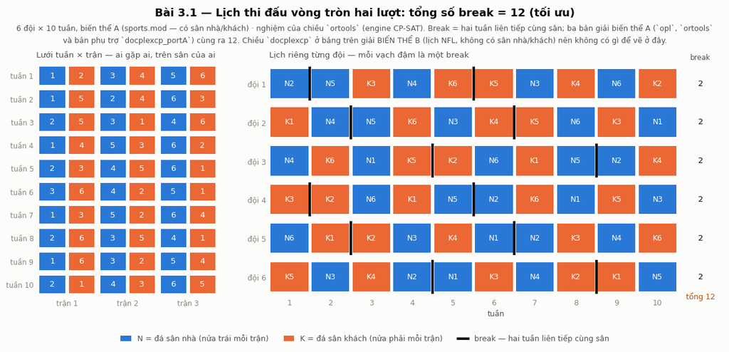

```python
show_solution("3.1_sports")
```

## (d) Quan sát so sánh

```python
show_notes("3.1_sports", "Quan sát")
```

(d) Quan sát so sánh

d.1 — Bảng đối chiếu ràng buộc toàn cục: CP Optimizer vs CP-SAT

Đây là điểm so sánh đắt nhất của bài. Cột "biến phụ" đếm ở $n=6$ (10 tuần, 30 trận).

| # | CP Optimizer (`sports.mod`) | CP-SAT tương ứng | Có sẵn? | Biến phụ ($n=6$) |
| --- | --- | --- | --- | --- |
| (C1) | `allowedAssignments(playSlots, h, a, g)` — bảng 3 ngôi trên tupleset | `add_allowed_assignments([h,a,g], tuples)` | ✅ **1-1** | 0 |
| (C2) | `allDifferent(append(...))` | `add_all_different([...])` | ✅ **1-1** | 0 |
| (C3) | `inverse(allGames, allSlots)` | `add_inverse(flat, all_slots)` | ✅ **1-1**, nhưng CP-SAT **bắt buộc** miền $0..k-1$ còn OPL cho $1..k$ ⇒ phải dời gốc chỉ số | 0 |
| (C4) | `((allSlots[g]-1) div γ) + 1` — `div` viết thẳng trong biểu thức | `add_division_equality(ω, σ, γ)` — phải gọi ràng buộc chuyên dụng | ⚠️ có, khác cách viết | 0 |
| (C5) | `(ω[m1] >= μ) == (ω[m2] < μ)` — engine tự **reify** hai bất đẳng thức rồi so bằng | tạo bool $z_m$, buộc hai chiều bằng `only_enforce_if`, rồi `z[m1] + z[m2] == 1` | ❌ **phải diễn đạt vòng** | **30** bool |
| (C6) | `abs(ω[m1] - ω[m2]) >= δ` — `abs` là **biểu thức**, dùng ngay tại chỗ | `add_abs_equality(d, ω[m1]-ω[m2])` rồi `d >= δ` — `abs` phải **vật chất hoá** thành biến | ❌ phải thêm biến | **15** int |
| (C7) | `playHome[t][w] == count(home[w][*], t)` — `count` là **biểu thức số** | không có `count`. Mã hoá **1-hot** toàn bộ `home[w][g]` bằng `add_map_domain`, rồi $p_{t,w}=\sum_g$ bool | ❌ **phải diễn đạt vòng** | **180** bool |
| (C8) | `1 <= sum(...) <= 2` | `add_linear_constraint(sum, 1, 2)` | ✅ 1-1 | 0 |
| (C9) | `sum(w)(playHome[t][w-1] == playHome[t][w])` — cộng thẳng **biểu thức so sánh** vào một tổng | mỗi số hạng phải là bool được buộc hai chiều bằng `only_enforce_if` | ❌ phải diễn đạt vòng | **54** bool |
| (C10)(C11) | tuyến tính | tuyến tính | ✅ 1-1 | 0 |
| (C12) | `teamBreaks[t] % 2 == 0` — `%` là biểu thức | `add_modulo_equality(r, β, 2)` rồi `r == 0` — cần biến đích | ⚠️ có, cần biến phụ | **6** int |
| (C13)(C14) | gán/so sánh trực tiếp | như nhau | ✅ 1-1 | 0 |
|  |  |  |  | **Tổng: 285** |

**Kết luận rút ra từ bảng.**

**1. Ba trong bốn ràng buộc toàn cục "đặc thù CP Optimizer" hoá ra CP-SAT cũng có.** Giả định ban đầu ở `PLAN.md` §4 — *"`sports.mod` dùng `allowedAssignments`, `inverse`, `count` — CP-SAT không có tương đương trực tiếp"* — **chỉ đúng một phần ba**. `add_allowed_assignments`, `add_all_different`, `add_inverse` đều tồn tại và cùng ngữ nghĩa. Chỉ có **`count` là thật sự thiếu**.

**2. Nhưng khoảng cách thật không nằm ở danh mục ràng buộc — nó nằm ở khả năng REIFY.** Nhìn cột "biến phụ": bốn dòng tốn kém nhất là (C5), (C6), (C7), (C9), và cả bốn có chung một nguyên nhân. Trong OPL/docplex.cp, **một ràng buộc cũng là một biểu thức**: `abs(...)`, `count(...)`, `(a == b)`, `(ω >= μ)` dùng được ngay tại chỗ như một số hạng. Trong CP-SAT, mọi thứ như vậy phải **vật chất hoá thành biến rồi buộc hai chiều bằng tay**. Đó mới là khác biệt engine, không phải chuyện thiếu vài cái tên hàm.

**3. Cái giá đo được: +132% số biến.**

|  | biến | ràng buộc | log₂ không gian tìm kiếm |
| --- | --- | --- | --- |
| CP Optimizer (`sports.mod`, $n=6$) | **216** | 271 | 510.6 (đo từ log engine) |
| CP Optimizer (`sports_portA_cp.py`) | **216** | 259 | 510.6 |
| CP-SAT (`sports_sat.py`) | **501** | 808 | — (CP-SAT không báo đại lượng này) |

$501 = 216 + 285$ — **khớp đúng đến từng biến** với cột "biến phụ" của bảng trên. Ở $n=10$ con số biến phụ là **1 215**.

**4. `add_map_domain` là công cụ chuẩn để thay `count`.** Không có `count`, cách diễn đạt vòng chuẩn là mã hoá 1-hot: `add_map_domain(home[w][g], col, offset=1)` tạo $n$ bool với `col[t-1] ⇔ home[w][g] == t`, rồi $p_{t,w}=\sum_g \text{col}_t$. Giá là $W\cdot\gamma\cdot n$ bool — $10\cdot3\cdot6=180$ ở $n=6$, tăng theo $\Theta(n^3)$. Đây là dòng đắt nhất bảng, và cũng là ví dụ sạch nhất cho luận điểm "CP-SAT quy mọi thứ về SAT nên phải bung ra biến bool".

d.2 — Trục NGÔN NGỮ: OPL vs DOcplex.cp (cùng engine CP Optimizer, cùng bài, $n=6$)

Hai bản dựng **cùng 216 biến, cùng $\log_2$ không gian tìm kiếm 510.6**, chạy với **cùng tham số engine** (`TimeLimit=60`, `DefaultInferenceLevel="Extended"` — đúng những gì khối `execute` của `sports.mod` đặt). Trung vị 3 lần chạy:

|  | Obj | Ràng buộc | Thời gian | Nhánh | Fails |
| --- | --- | --- | --- | --- | --- |
| `opl/sports.mod` | 12 | 271 | **1.51 s** | **556 103** | **280 303** |
| `docplexcp/sports_portA_cp.py` | 12 | 259 | 2.37 s | 850 352 | 429 850 |
| tỉ lệ | = |  | **1.57× chậm hơn** | **1.53× nhiều nhánh hơn** | 1.53× |

Cả hai bản đều **tất định tuyệt đối** — ba lần chạy cho đúng cùng một con số nhánh.

**Đọc kết quả.** Cùng engine, cùng mô hình toán, cùng số biến, cùng không gian tìm kiếm — mà lệch 1.5× cả thời gian lẫn số nhánh. Nguyên nhân là **thứ tự và cách bung ràng buộc của hai front-end khác nhau** (271 so với 259 ràng buộc sau khi trích xuất), đủ để đổi thứ tự duyệt của heuristic mặc định. Đây là **dẫn chứng thứ hai** cho luận điểm "khác biệt do ngôn ngữ" của báo cáo, sau dẫn chứng N-Queens ở `PLAN.md` §2.2 (440/198 nhánh của OPL so với 255/99 của DOcplex.cp).

Khác biệt so với bài N-Queens: ở đó OPL **buộc phải** viết dài hơn (`allDifferent` không nhận mảng biểu thức). Ở bài này thì ngược lại — **OPL diễn đạt được mọi thứ gọn hơn hoặc bằng** docplex.cp:

| Ý | OPL | docplex.cp |
| --- | --- | --- |
| bảng 3 ngôi | `allowedAssignments(playSlots, h, a, g)` — nhận thẳng một `{PlaySlotTuple}` có `key` | `mdl.allowed_assignments([h,a,g], tuples)` — phải tự dựng `list[tuple]` |
| gốc chỉ số của `inverse` | theo **range khai báo** của mảng (ở đây $1..M$) | **cố định 0-based** — phải dời gốc id trận |
| bất đẳng thức kép | `1 <= expr <= 2` viết tự nhiên | phải gọi `mdl.range(expr, 1, 2)` |
| tổng có điều kiện | `sum(w in 2..W)(p[w-1] == p[w])` | `sum((p[w-1] == p[w]) for w in ...)` — tương đương |

⇒ Kết luận cho báo cáo: **ưu thế cú pháp không cố định về một phía.** OPL thắng ở bài giàu tupleset và range (3.1); Python thắng ở bài cần mảng biểu thức (1.2).

d.3 — Trục ENGINE: CP Optimizer vs CP-SAT (cùng ngôn ngữ Python, cùng bài, $n=6$)

|  | Engine | Obj | Biến | Thời gian | Nhánh | Fails / Conflicts |
| --- | --- | --- | --- | --- | --- | --- |
| `sports_portA_cp.py` | CP Optimizer | **12** | 216 | 2.37 s | 850 352 | 429 850 |
| `sports_sat.py` (`--workers 8`) | CP-SAT | **12** | 501 | **0.78 s** | 1 350 | 0 |
| `sports_sat.py` (**mặc định**: 1 worker, seed 0) | CP-SAT | **12** | 501 | 3.06 s | 80 264 | 9 150 |

> Từ nay `sports_sat.py` **mặc định** chạy `--workers 1 --seed 0`; muốn số liệu 8 worker thì phải truyền cờ tường minh. Cột thời gian là trung vị 3 lần chạy.

> `fails` của CP Optimizer và `conflicts` của CP-SAT đếm hai thứ khác nhau, chỉ so được trong cùng một engine (xem `README.md`).

**1. Hai lối tìm kiếm khác hẳn nhau.** CP-SAT một worker duyệt **80 264** nhánh, CP Optimizer duyệt **850 352** — gấp **10.6 lần** — mà hai bên về đích cùng cỡ thời gian (3.06 s so với 2.37 s). CP Optimizer duyệt ồ ạt với chi phí mỗi nhánh rất rẻ (**359 000 nhánh/giây**); CP-SAT duyệt ít hơn hẳn nhờ học mệnh đề xung đột nhưng mỗi nhánh đắt hơn (**26 000 nhánh/giây**). Đúng cùng một kết luận đã thấy ở bài 3.2.

**2. Ưu thế của CP-SAT ở đây là ĐA LUỒNG, không phải mỗi-nhánh-thông-minh-hơn.** Bật 8 worker, CP-SAT về đích trong 0.78 s và chỉ duyệt ~1 350 nhánh — nhanh hơn 3.9× so với chính nó chạy một luồng. Các worker chạy chiến lược khác nhau (LNS, no-LP, core-based…) và worker nào gặp may thì kéo cả nhóm về đích. CP Optimizer bản Community cũng dùng 16 worker song song (log ghi rõ) nhưng không thu được lợi tương đương trên bài này.

**3. Giá phải trả: số liệu CP-SAT không tái lập được.** Ba lần chạy 8 worker cho **826 / 1 350 / 2 648** nhánh và **0 / 0 / 41** conflicts, trong khi objective và thời gian gần như không đổi. Cố định `num_workers=1` + `random_seed=0` thì số liệu tất định tuyệt đối (**80 264 / 9 150** ở cả ba lần chạy liên tiếp). Đây là **xác nhận độc lập** cho `PLAN.md` §2.4 trên một bài toán thứ hai ⇒ mọi bảng benchmark của báo cáo bắt buộc phải cố định worker và seed, và đó là **mặc định** của `sports_sat.py`.

d.4 — Trần Community Edition: chỗ CP-SAT thắng tuyệt đối

Bản gốc của IBM đặt $n=10$. Trên **CPLEX Studio Community Edition** thì cả hai chiều CP Optimizer đều **không chạy nổi bản gốc**:

| $n$ | Tuần | log₂ KGTK | OPL / DOcplex.cp (CP Optimizer Community) | OR-Tools (CP-SAT) |
| --- | --- | --- | --- | --- |
| **6** | 10 | **510.6** (đo được) | ✅ tối ưu **12** — 1.51 s | ✅ tối ưu **12** — 3.06 s *(mặc định 1 worker)* / 0.78 s *(`--workers 8`)* |
| 8 | 14 | ≈1 090 (ước tính) | ❌ `FATAL[ENGINE_001]: Problem size limit exceeded` | ✅ tối ưu **16** — 14.8 s, **chỉ với `--workers 8`** |
| **10** *(cỡ bản gốc IBM)* | 18 | ≈1 925 (ước tính) | ❌ `FATAL[ENGINE_001]` | ✅ tối ưu **16** — 17.9 s, **chỉ với `--workers 8`** |

> ⚠️ **Hai dòng $n=8$ và $n=10$ chỉ đạt được nhờ ĐA LUỒNG.** Chạy đúng cấu hình tái lập (mặc định 1 worker, seed 0, `--time-limit 300`) thì CP-SAT **không đóng nổi** hai cỡ bài này: $n=8$ chạm giới hạn 300 s ở trạng thái `FEASIBLE` với objective 16 (1 822 928 nhánh, 594 403 conflicts) — tức tìm ra lời giải tối ưu nhưng **không chứng minh được**; $n=10$ chạm 300 s ở `FEASIBLE` với objective **28**, còn xa nghiệm 16. Vì vậy hai dòng này **không** dùng chung cấu hình với bảng d.3 và không vào bất kỳ bảng benchmark tái lập nào — chúng là bằng chứng về *trần license*, không phải điểm đo hiệu năng.

Thông báo lỗi thật (cả `oplrun` lẫn `docplex.cp` đều báo giống nhau):

```
*** FATAL[ENGINE_001]: Exception from IBM ILOG Concert: Problem size limit exceeded.
CP Optimizer Community Edition solves problems with search spaces up to 2^1000.
```

$n=6$ là **giá trị lớn nhất chạy được** trên bản Community. Ba nhận xét:

1. **Trần 2^1000 là trần LICENSE, không phải trần thuật toán.** Với license academic thì $n=10$ chạy bình thường; đây là giới hạn thương mại của IBM.

2. **CP-SAT không có trần nào tương ứng** — và bản port có **nhiều hơn 132% số biến** mà vẫn *dựng và giải được* cỡ bài gấp ba. Nghịch lý biểu kiến này chính là điểm đáng nói: mã hoá "cồng kềnh" hơn không phải là bất lợi khi engine sinh ra để nuốt biến bool. Nhưng phải nói đủ: ở $n\ge 8$, việc **đóng** được bài trong 300 s là công của 8 worker chạy song song, không phải của một luồng đơn (xem cảnh báo trên).

3. Đây là dẫn chứng cụ thể cho luận điểm **hạ tầng/giấy phép cũng là một chiều so sánh**, ngang hàng với ngôn ngữ và engine: `ortools` là thư viện Apache-2.0 cài bằng `pip install`, còn CP Optimizer đòi cài Studio và bị chặn theo cỡ bài.

d.5 — Ghi chú về chiều `docplexcp` (biến thể B)

Chiều này giải bài khác nên không vào hai bảng trên. Số liệu để tham khảo ($n=6$, $W=10$, 60 s):

| Status | Obj | Thời gian | Nhánh | Fails |
| --- | --- | --- | --- | --- |
| Feasible (**không chứng minh được tối ưu**) | 208 | 60.0 s (chạm giới hạn) | **79 268 907** | 38 573 731 |

# Bài 3.2 — Xếp thời khoá biểu có ràng buộc khả dụng

## (a) Phát biểu bài toán

```python
show_notes("3.2_timetable", "Phát biểu")
```

(a) Phát biểu bài toán

Xếp thời khoá biểu cho một trường: mỗi lớp phải học đủ số tiết từng môn, mỗi môn do một giáo viên có chuyên môn phù hợp dạy, học trong một phòng phù hợp. Giáo viên, lớp và phòng đều chỉ ở một chỗ tại một thời điểm. Mục tiêu: **tối thiểu makespan** — kết thúc toàn bộ chương trình sớm nhất có thể.

Phần bài 3.2 thêm vào so với bản gốc là **ràng buộc khả dụng** (availability windows): giáo viên có lịch bận, lớp có lịch bận, và mỗi môn có khung giờ cần tránh.

## (b) Mô hình toán học

Mô hình dưới đây là **hợp đồng chung** mà cả ba chiều cùng cài đặt. Ba đoạn code ở mục (c) chỉ là ba cách diễn đạt đúng mô hình này.

```python
show_notes("3.2_timetable", "Mô hình toán")
```

(b) Mô hình toán học — dùng chung cho cả ba chiều

> Mô hình dưới đây mô tả đúng những gì ba chiều cài đặt. Nó **thay thế** bản phác thảo ở brief §4: bản đó dùng mã hoá nhị phân $X_{c,t,d,p}$ và bỏ sót phòng học, thời lượng, số lần lặp, giờ nghỉ và môn buổi sáng.

Tập hợp

| Ký hiệu | Ý nghĩa |
| --- | --- |
| $\mathcal{C}$ | tập lớp |
| $\mathcal{S}$ | tập môn |
| $\mathcal{T}$ | tập giáo viên |
| $\mathcal{R}$ | tập phòng |
| $\mathcal{K}\subseteq\mathcal{T}\times\mathcal{S}$ | chuyên môn: $(t,s)\in\mathcal{K}$ nghĩa là $t$ dạy được $s$ |
| $\mathcal{D}\subseteq\mathcal{R}\times\mathcal{S}$ | phòng chuyên dụng: $(r,s)\in\mathcal{D}$ nghĩa là phòng $r$ dành cho môn $s$ |
| $\mathcal{B}\subseteq\mathcal{S}\times\mathcal{S}$ | cặp môn kỵ nhau, cần giãn cách |
| $\mathcal{M}\subseteq\mathcal{S}$ | môn chỉ được học buổi sáng |
| $\mathcal{Q}$ | chương trình học |

Tham số

$$H=\text{số tiết mỗi ngày},\quad H_2=\tfrac{H}{2},\quad N_d=\text{số ngày},\quad T_{\max}=H\!\cdot\!N_d,\quad \beta=\text{độ dài giãn cách}$$

Trục thời gian $\mathcal{H}=\{0,1,\dots,T_{\max}-1\}$, đánh số tiết liên tục qua các ngày. Tiết $u$ thuộc ngày $\lfloor u/H\rfloor$ và buổi $\lfloor u/H_2\rfloor$.

Từ chương trình học sang các buổi học

Mỗi phần tử $q=(c_q,\,s_q,\,p_q,\,n_q)\in\mathcal{Q}$ đọc là: *lớp $c_q$ phải học môn $s_q$ thành $n_q$ buổi, mỗi buổi dài $p_q$ tiết.* Tách ra thành tập **buổi học**

$$\mathcal{I}=\bigl\{\,(q,k)\;:\;q\in\mathcal{Q},\ k\in\{1,\dots,n_q\}\,\bigr\}$$

Với $i=(q,k)\in\mathcal{I}$ viết gọn $c_i=c_q$, $s_i=s_q$, $p_i=p_q$, $q_i=q$, $k_i=k$.

Tài nguyên dùng được

$$\mathcal{T}_s=\{t\in\mathcal{T}:(t,s)\in\mathcal{K}\}$$

$$\mathcal{R}_s=\underbrace{\{r:(r,s)\in\mathcal{D}\}}_{\text{phòng chuyên dụng của } s} \;\cup\; \underbrace{\{r: r\notin\Pi_\mathcal{R}(\mathcal{D})\ \wedge\ s\notin\Pi_\mathcal{S}(\mathcal{D})\}}_{\text{phòng thường, khi } s \text{ không đòi phòng riêng}}$$

trong đó $\Pi_\mathcal{R},\Pi_\mathcal{S}$ là phép chiếu $\mathcal{D}$ xuống thành phần phòng và thành phần môn. Nói bằng lời: môn có phòng riêng thì chỉ học ở phòng riêng đó; môn không đòi phòng riêng thì học ở bất kỳ phòng nào không bị dành riêng cho môn khác.

Biến quyết định

| Biến | Miền | Ý nghĩa |
| --- | --- | --- |
| $\sigma_i$ | $\mathcal{H}$ | tiết bắt đầu của buổi $i$ |
| $\eta_i$ | $\mathcal{H}$ | tiết kết thúc (hở phải): buổi $i$ chiếm $[\sigma_i,\eta_i)$ |
| $\theta_i$ | $\mathcal{T}_{s_i}$ | giáo viên dạy buổi $i$ |
| $\mu_i$ | $\mathcal{R}_{s_i}$ | phòng học buổi $i$ |
| $\gamma_{c,s}$ | $\mathcal{T}$ | giáo viên cố định của cặp (lớp $c$, môn $s$) |
| $\omega$ | $\mathcal{H}$ | makespan |

Việc $\theta_i$ và $\mu_i$ lấy miền $\mathcal{T}_{s_i}$, $\mathcal{R}_{s_i}$ đã **nuốt luôn** hai ràng buộc "giáo viên phải đủ chuyên môn" và "phòng phải phù hợp" vào trong khai báo biến — không cần viết thành ràng buộc riêng. Đây là nét đặc trưng của CP đã gặp ở bài 1.2 với N-Queens.

> Lưu ý: $\eta_i\in\mathcal{H}$ nên $\eta_i\le T_{\max}-1$, tức tiết cuối cùng của kỳ không bao giờ được dùng. Đây là đặc điểm của bản OPL gốc; hai chiều còn lại giữ nguyên để ba chiều so được với nhau.

Ràng buộc

**Cấu trúc thời gian**

$$\eta_i=\sigma_i+p_i \qquad \forall i\in\mathcal{I} \tag{C1}$$

$$\sigma_i<\sigma_j \qquad \forall i,j\in\mathcal{I}:\ q_i=q_j,\ k_i<k_j \tag{C2}$$

(C2) đánh số các buổi của cùng một môn theo đúng thứ tự thời gian — vừa hợp lẽ, vừa phá đối xứng giữa các buổi giống hệt nhau, giúp engine chứng minh tối ưu nhanh hơn.

**Tài nguyên chỉ ở một chỗ tại một thời điểm.** Với mọi $i\ne j$:

$$c_i=c_j \;\Longrightarrow\; [\sigma_i,\eta_i)\cap[\sigma_j,\eta_j)=\varnothing \tag{C3}$$ $$\theta_i=\theta_j \;\Longrightarrow\; [\sigma_i,\eta_i)\cap[\sigma_j,\eta_j)=\varnothing \tag{C4}$$ $$\mu_i=\mu_j \;\Longrightarrow\; [\sigma_i,\eta_i)\cap[\sigma_j,\eta_j)=\varnothing \tag{C5}$$

Ba ràng buộc này là chỗ **ba chiều mã hoá khác nhau** — xem mục kế tiếp.

**Ổn định phân công**

$$\theta_i=\gamma_{c_i,\,s_i} \qquad \forall i\in\mathcal{I} \tag{C6}$$

Một lớp học một môn thì suốt kỳ chỉ một giáo viên dạy.

**Ràng buộc lịch**

$$p_i>1 \;\Longrightarrow\; \Bigl\lfloor \tfrac{\sigma_i}{H_2}\Bigr\rfloor=\Bigl\lfloor \tfrac{\eta_i-1}{H_2}\Bigr\rfloor \tag{C7}$$

$$s_i\in\mathcal{M} \;\Longrightarrow\; \sigma_i \bmod H < H_2 \tag{C8}$$

$$c_i=c_j,\ s_i=s_j,\ i\ne j \;\Longrightarrow\; \Bigl\lfloor\tfrac{\sigma_i}{H}\Bigr\rfloor\ne\Bigl\lfloor\tfrac{\sigma_j}{H}\Bigr\rfloor \tag{C9}$$

(C7) buổi dài hơn một tiết không được vắt qua giờ nghỉ trưa. (C8) môn buổi sáng phải bắt đầu trong buổi sáng. (C9) một lớp không học cùng một môn hai lần trong một ngày.

**Giãn cách giữa hai môn kỵ nhau.** Với $i\ne j$, $c_i=c_j$, và $(s_i,s_j)\in\mathcal{B}$ hoặc $(s_j,s_i)\in\mathcal{B}$:

$$\Bigl\lfloor\tfrac{\sigma_i}{H}\Bigr\rfloor\ne\Bigl\lfloor\tfrac{\sigma_j}{H}\Bigr\rfloor \;\;\vee\;\; \Bigl\lfloor\tfrac{\sigma_i}{H_2}\Bigr\rfloor\ne\Bigl\lfloor\tfrac{\sigma_j}{H_2}\Bigr\rfloor \;\;\vee\;\; g_{ij}\ \ge\ \beta \tag{C10}$$

$$g_{ij}=\max(0,\ \sigma_i-\eta_j)+\max(0,\ \sigma_j-\eta_i)$$

Khác ngày, hoặc khác buổi, hoặc cách nhau đủ $\beta$ tiết. Do (C3) hai buổi cùng lớp không chồng nhau nên nhiều nhất một số hạng của $g_{ij}$ dương — nó đúng bằng khoảng trống giữa hai buổi.

Phần bài 3.2 bổ sung — ràng buộc khả dụng

Dữ liệu vào thêm ba tập lịch bận:

$$\mathcal{U}^{T}\subseteq\mathcal{T}\times\mathcal{H},\qquad \mathcal{U}^{C}\subseteq\mathcal{C}\times\mathcal{H},\qquad \mathcal{U}^{S}\subseteq\mathcal{S}\times\mathcal{H}$$

lần lượt là lịch bận của giáo viên, lịch bận của lớp, và khung giờ cần tránh của môn. Đặt vị từ "buổi $i$ **không** phủ tiết $u$":

$$\mathrm{free}(i,u)\;\equiv\;u\notin[\sigma_i,\eta_i)\;\equiv\;\bigl(\sigma_i>u\ \vee\ \eta_i\le u\bigr)$$

$$\theta_i=t \;\Longrightarrow\; \mathrm{free}(i,u) \qquad \forall i\in\mathcal{I},\ \forall (t,u)\in\mathcal{U}^{T} \tag{RB7}$$

$$\mathrm{free}(i,u) \qquad \forall i\in\mathcal{I},\ \forall (c,u)\in\mathcal{U}^{C}:\ c_i=c \tag{RB8}$$

$$\mathrm{free}(i,u) \qquad \forall i\in\mathcal{I},\ \forall (s,u)\in\mathcal{U}^{S}:\ s_i=s \tag{RB4}$$

Chú ý bất đối xứng: (RB7) phải viết dạng kéo theo vì $\theta_i$ là **biến**, còn (RB8) và (RB4) lọc thẳng ở chỉ số vì $c_i,s_i$ là **hằng** của buổi học. Bất đối xứng này hiện ra trong cả ba bản cài đặt.

Hàm mục tiêu

$$\omega=\max_{i\in\mathcal{I}}\eta_i, \qquad \omega\ \ge\ \max_{c\in\mathcal{C}}\sum_{i\,:\,c_i=c}p_i \tag{C11}$$

$$\boxed{\ \min\ \omega\ }$$

Bất đẳng thức trong (C11) là **chặn dưới hợp lệ**: một lớp có tổng $P$ tiết thì không thể học xong trước tiết $P$, vì (C3) cấm lớp học hai buổi cùng lúc. Nó không đổi tập nghiệm tối ưu, chỉ giúp engine chứng minh tối ưu sớm hơn.

Ba chiều mã hoá (C3)–(C5) theo ba cách

Cùng một mô hình toán ở trên, ba chiều diễn đạt phần "tài nguyên dùng một lần tại mỗi thời điểm" bằng ba cách khác nhau. **Đây là biến số mà bài 3.2 đo.**

**① OPL — đếm có điều kiện.** Hai đoạn giao nhau thì điểm bắt đầu muộn hơn luôn nằm trong đoạn kia, nên (C3) tương đương: với mọi $i$, số buổi cùng lớp bắt đầu trong $[\sigma_i,\eta_i)$ không quá 1.

$$\sum_{j\,:\,c_j=c_i}\mathbb{1}\bigl[\sigma_i\le\sigma_j<\eta_i\bigr]\ <\ 2 \qquad\forall i$$

Sinh $O(|\mathcal{I}|^2)$ tích có điều kiện — nguồn gốc của con số 17.9 s ở bảng benchmark.

**② DOcplex.cp — biến interval, `alternative` + `no_overlap`.** Mỗi buổi là một biến interval $x_i$; mỗi tài nguyên dùng được sinh một interval tuỳ chọn; `alternative` chọn đúng một.

$$\texttt{no\_overlap}\bigl(\{x_i : c_i=c\}\bigr)\quad\forall c\in\mathcal{C}$$

**③ OR-Tools — biến interval + literal hiện diện.** Cùng ý tưởng interval, nhưng CP-SAT không có `alternative` nên phải dựng tay: $\pi_{i,t}\in\{0,1\}$ với $\pi_{i,t}=1\iff\theta_i=t$, rồi `add_no_overlap` trên các interval tuỳ chọn.

Ba cách **tương đương về tập nghiệm** — đã kiểm chứng chéo ở mục dưới — nhưng khác hẳn về sức lan truyền và chi phí mỗi nhánh.

## (c) Cài đặt ba chiều

### OPL → engine CP Optimizer

```python
show_dimension_code("3.2_timetable", "opl")
```

**OPL → engine CP Optimizer · ✅+✍️ mẫu chính thức, có mở rộng**

```
opl
// --------------------------------------------------------------------------
// Licensed Materials - Property of IBM
//
// 5725-A06 5725-A29 5724-Y48 5724-Y49 5724-Y54 5724-Y55
// Copyright IBM Corporation 1998, 2026. All Rights Reserved.
//
// Note to U.S. Government Users Restricted Rights:
// Use, duplication or disclosure restricted by GSA ADP Schedule
// Contract with IBM Corp.
// --------------------------------------------------------------------------

using CP;

/*
 This model solves a school time tabling problem.
 Given teacher skills, room equipment and pupil course requirement,
 the model generates for each course a time table specifying :
    - a teacher
    - a start time
    - a room

constraints are used to:

   - ensure the course ends after it starts
   - ensure course numerotation is chronological
   - ensure that a teacher is required once at any time point.
   - ensure the teacher can teach the discipline
   - ensure that a room is required once at any time point.
   - ensure the room can support the discipline
   - ensure that a class follows one course at a time
   - ensure that for given class and discipline, the teacher is always the same
   - ensure a course starts and end the same halfday
   - insert break duration between specified disciplines
   - avoid to have the same discipline taught twice a day
   - ensure that the morning disciplines end in the morning


Note: To reduce the amount of decision variable, we choose to use
course start times as time points where uniqueness of resources (classes,
```

[output cut: 284 more lines]

```
  }
}


// ===== BỔ SUNG — dòng RESULT theo giao kèo của tools/runner.py =====
execute EMIT_RESULT {
  writeln("RESULT {\"status\":\"Optimal\""
        + ",\"objective\":" + makespan
        + ",\"solve_time_s\":" + cp.info.solveTime
        + ",\"branches\":" + cp.info.numberOfBranches
        + ",\"fails\":" + cp.info.numberOfFails
        + ",\"nb_teacher_busy\":" + TeacherBusySet.size
        + ",\"nb_class_busy\":" + ClassBusySet.size
        + ",\"nb_discipline_avoid\":" + DisciplineAvoidSet.size + "}");
}
```

### DOcplex.cp → engine CP Optimizer

```python
show_dimension_code("3.2_timetable", "docplexcp")
```

**Python (docplex.cp) → engine CP Optimizer · ✍️ viết mới**

```
"""Bài 3.2 — Thời khoá biểu có ràng buộc khả dụng | Chiều DOcplex.cp (engine CP Optimizer)

Nguồn: ✍️ VIẾT MỚI. IBM không phát hành bản CP nào của bài xếp thời khoá biểu qua
`docplex.cp` (chỉ có `timetabling.mod` bằng OPL). Bản này dựng lại đúng mô hình đó
bằng Python, cộng ba nhóm ràng buộc khả dụng RB7/RB8/RB4.

Đọc ĐÚNG những file `.dat` gốc mà hai chiều kia dùng, qua `tools/opl_dat.py`.

Chạy:
    python3 models/3.2_timetable/docplexcp/timetable_cp.py \\
        data/timetable/base.dat data/timetable/large.dat data/timetable/availability.dat

VAI TRÒ CỦA CHIỀU NÀY TRONG BÁO CÁO
------------------------------------
Đây là điểm đo thứ ba, và là điểm đo duy nhất tách bạch được hai nguyên nhân:

    OPL (CP Optimizer + đếm có điều kiện)
      ──vs── bản này (CP Optimizer + interval)      → cô lập ảnh hưởng của MÃ HOÁ
      ──vs── OR-Tools (CP-SAT + interval)           → cô lập ảnh hưởng của ENGINE

So thẳng OPL với OR-Tools thì hai yếu tố đổi cùng lúc nên không kết luận được gì.

HAI PRIMITIVE CỦA CP OPTIMIZER MÀ CP-SAT KHÔNG CÓ
--------------------------------------------------
1. `alternative(master, [alt1, alt2, ...])` — chọn đúng một tài nguyên trong nhiều
   lựa chọn, tự đồng bộ thời gian với interval chính. Bản CP-SAT phải làm tay:
   tạo literal hiện diện cho từng cặp (khoá học, tài nguyên) rồi tự buộc chúng
   khớp với biến chọn tài nguyên.

2. `forbid_extent(interval, F)` + hàm bậc thang — cấm một interval phủ lên vùng mà
   F bằng 0. Đây là cách diễn đạt LỊCH BẬN đúng nghĩa: khai báo trực tiếp lịch của
   tài nguyên, không cần biến phụ nào. Bản CP-SAT phải bung thành phép tuyển
   "bắt đầu sau t HOẶC kết thúc trước t" kèm một biến bool cho mỗi cặp
   (khoá học, thời điểm bận).

Ba nhóm ràng buộc khả dụng ở đây vì thế **không sinh thêm một biến quyết định nào**
— chúng chỉ là dữ liệu lịch gắn vào interval. Đây là thế mạnh 20 năm chuyên biệt
của CP Optimizer cho bài lập lịch mà brief §1 đã nêu.
"""

```

[output cut: 274 more lines]

```
                where = next(rooms[r] for r in xr[i]
                             if sol.get_var_solution(xr[i][r]).is_present())
                print(
                    f"  ngày {s_val // day_duration + 1} tiết {s_val % day_duration + 1}"
                    f"  {inst.discipline:<10} {who:<14} phòng {where}"
                )
    return result


if __name__ == "__main__":
    files = [a for a in sys.argv[1:] if a.endswith(".dat")]
    if not files:
        files = ["data/timetable/base.dat", "data/timetable/large.dat",
                 "data/timetable/availability.dat"]
    print("RESULT " + json.dumps(build_and_solve(files)))
```

### OR-Tools → engine CP-SAT

```python
show_dimension_code("3.2_timetable", "ortools")
```

**Python (ortools.sat) → engine CP-SAT · ✍️ viết mới**

```
"""Bài 3.2 — Thời khoá biểu có ràng buộc khả dụng | Chiều OR-Tools (engine CP-SAT)

Nguồn: ✍️ VIẾT MỚI. Port đầy đủ mô hình `timetabling.mod` của IBM (CPLEX Studio
22.2) sang CP-SAT, cộng ba nhóm ràng buộc khả dụng RB7/RB8/RB4 mà bản gốc không có.

Đọc ĐÚNG những file `.dat` gốc mà chiều OPL dùng, qua `tools/opl_dat.py` — ba
chiều không có bản dữ liệu riêng nào để lệch nhau.

Chạy:
    python3 models/3.2_timetable/ortools/timetable_sat.py \\
        data/timetable/base.dat data/timetable/large.dat data/timetable/availability.dat

    # bỏ availability để đo chi phí của nó:
    python3 models/3.2_timetable/ortools/timetable_sat.py \\
        data/timetable/base.dat data/timetable/large.dat

    # cờ tuỳ chọn: --workers N (mặc định 1), --seed S (mặc định 0). Giữ nguyên mặc
    # định khi đo benchmark — đa luồng làm số liệu không tái lập được (PLAN.md §2.4).

KHÁC BIỆT MÃ HOÁ SO VỚI BẢN OPL (điểm so sánh cốt lõi của bài này)
------------------------------------------------------------------
Bản OPL gốc diễn đạt "tài nguyên chỉ dùng một lần tại mỗi thời điểm" bằng TỔNG CÓ
ĐIỀU KIỆN — với mỗi khoá học r nó đếm xem có bao nhiêu khoá khác bắt đầu trong
khoảng [Start[r], End[r]) rồi bắt tổng đó < 2:

    (sum(o in InstanceSet : o.Class == x)
       (1 == (Start[o] >= Start[r])*(Start[o] < End[r]))) < 2;

Bản này dùng BIẾN INTERVAL + no-overlap, thứ cả CP Optimizer lẫn CP-SAT đều có
sẵn thuật toán lan truyền chuyên dụng:

    model.add_no_overlap([...các interval của cùng một lớp...])

Hai cách tương đương về nghiệm (hai đoạn giao nhau thì điểm bắt đầu muộn hơn luôn
nằm trong khoảng của đoạn kia), nhưng khác hẳn về sức lan truyền. Với tài nguyên
được chọn bằng BIẾN (giáo viên, phòng), ở đây dùng interval TUỲ CHỌN gắn literal
hiện diện — đúng cách mà một solver lập lịch mong nhận được bài toán.
"""

from __future__ import annotations
```

[output cut: 332 more lines]

```
        del argv[i : i + 2]
        return value
    return default


if __name__ == "__main__":
    argv = sys.argv[1:]
    # Mặc định 1 worker + seed cố định: số liệu phải tái lập được (PLAN.md §2.4).
    WORKERS = int(_take(argv, "--workers", "1"))
    SEED = int(_take(argv, "--seed", "0"))
    files = [a for a in argv if a.endswith(".dat")]
    if not files:
        files = ["data/timetable/base.dat", "data/timetable/large.dat",
                 "data/timetable/availability.dat"]
    print("RESULT " + json.dumps(build_and_solve(files, workers=WORKERS, seed=SEED)))
```

## Chạy — cả ba chiều, cùng một bộ dữ liệu

Bảng dưới sinh ra bằng cách **chạy thật** ba file code vừa in ở trên.

```python
run_table("3.2_timetable")
```

| chiều | ngôn ngữ | engine | nguồn | trạng thái | mục tiêu | thời gian giải (s) | nhánh | fails/conflicts |
| --- | --- | --- | --- | --- | --- | --- | --- | --- |
| opl | OPL | CP Optimizer | ✅+✍️ | Optimal | 47 | 7.058 | 125151 | 55086 |
| docplexcp | Python (docplex.cp) | CP Optimizer | ✍️ | Optimal | 47 | 1.272 | 154818 | 59201 |
| ortools | Python (ortools.sat) | CP-SAT | ✍️ | OPTIMAL | 47 | 2.1866 | 13305 | 183 |

### Kiểm chứng chéo

Ba chiều phải cùng ra một nghiệm tối ưu. Không có bước này thì mọi so sánh hiệu năng đều vô nghĩa — nhanh hơn mà giải sai bài thì không nói lên điều gì.

```python
cross_check("3.2_timetable")
```

**Kiểm chứng chéo — bài 3.2_timetable**

`opl` = 47 · `docplexcp` = 47 · `ortools` = 47 → ✅ **KHỚP** — các chiều cùng một nghiệm tối ưu

### Nghiệm tìm được

Hình dưới là **nghiệm của chiều `ortools`** (engine CP-SAT) — chiều duy nhất chạy được mà không cần giấy phép IBM, nên hình này dựng được trên mọi máy. Ba chiều vừa được kiểm chứng chéo ở ô ngay trên và **cùng ra một giá trị tối ưu** (makespan = 47), nên thời khoá biểu vẽ dưới đây là một hiện thân cụ thể của đúng cái tối ưu mà cả ba chiều đạt tới.

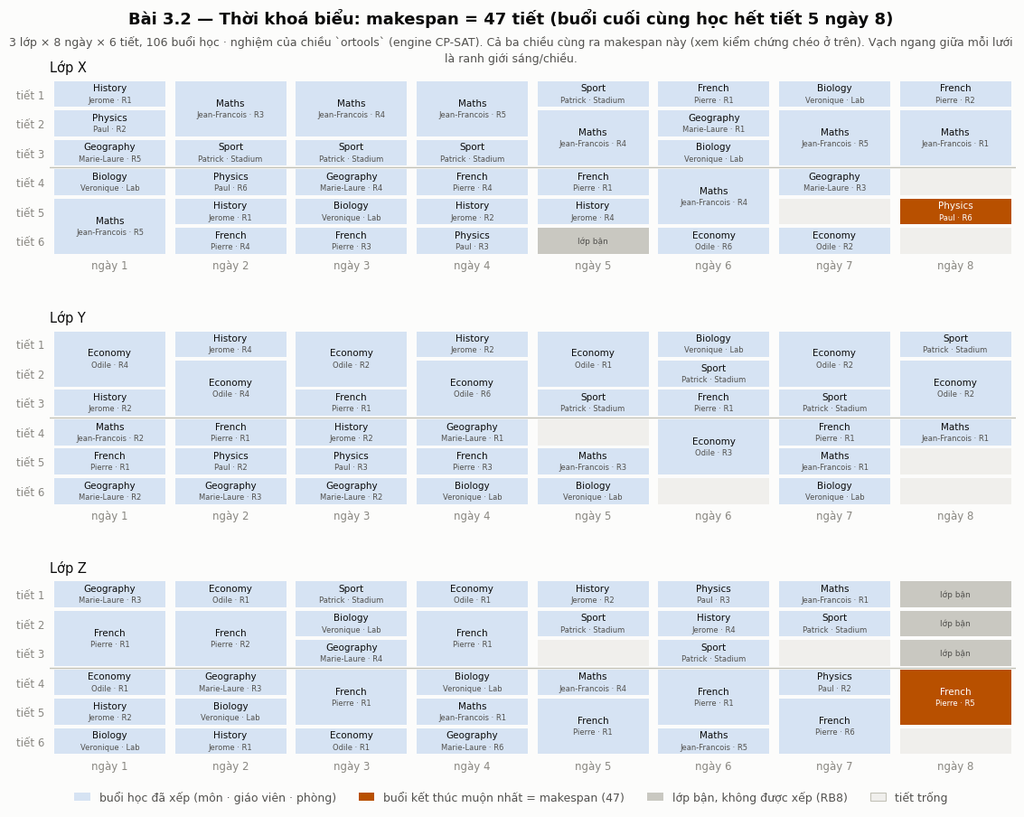

```python
show_solution("3.2_timetable")
```

## (d) Quan sát so sánh

```python
show_notes("3.2_timetable", "Quan sát")
```

(d) Quan sát cho phần so sánh

Chi phí của tính khả dụng

| Bộ `large` | log₂ không gian | Makespan | OPL | DOcplex.cp | OR-Tools |
| --- | --- | --- | --- | --- | --- |
| không availability | 786.4 | 44 | 17.94 s | 0.67 s | 2.52 s |
| có availability | **780.3** | 47 | 8.60 s | 1.50 s | 2.42 s |

| Bộ `small` | Makespan | OPL | DOcplex.cp | OR-Tools |
| --- | --- | --- | --- | --- |
| không availability | 20 | 0.39 s | 0.44 s | 0.051 s |
| có availability | 21 | 0.47 s | 0.36 s | 0.061 s |

Ba điều đáng nói:

1. **Thêm ràng buộc làm không gian tìm kiếm GIẢM** (786.4 → 780.3), dù số ràng buộc gần gấp đôi (2 120 → 3 947). Ràng buộc khả dụng chỉ cắt miền của biến sẵn có chứ không thêm biến mới. Community Edition tính trần theo *không gian tìm kiếm* chứ không theo *số ràng buộc* — nên còn nhiều chỗ để thêm ràng buộc nữa.

2. **Cái giá của tính khả dụng nằm ở chất lượng lời giải, không ở thời gian giải.** Makespan xấu đi 44 → 47, còn thời gian giải thì tuỳ chiều: OPL *nhanh hơn* hẳn (17.94 → 8.60 s) vì miền bị cắt bớt, DOcplex.cp chậm lại, OR-Tools gần như không đổi (2.52 → 2.42 s). Ràng buộc thực tế hơn làm lịch dài ra, chứ không làm bài toán khó hơn về tính toán.

3. **Hiện tượng đó lặp lại y hệt ở bộ nhỏ**, chỉ khác biên độ: makespan 20 → 21, OPL chậm lại một chút còn DOcplex.cp nhanh lên (0.44 → 0.36 s). Hai kích thước cùng nói một điều thì kết luận mới đứng được — mà muốn vậy thì bộ small phải có file availability của riêng nó, xem mục ngay dưới.

Ràng buộc khả dụng chỉ có nghĩa khi nó nằm trong tầm dữ liệu

Ô `small+avail` của lưới 2×2 đã từng **rỗng nghĩa**: nó cho số trùng khít từng chữ số với ô `small` ở cả ba chiều (makespan 20; 30 412 / 75 025 / 553 nhánh). Không phải lỗi script, cũng không phải lỗi mô hình — mà vì cả bốn ô cùng dùng `availability.dat`, một file viết cho bộ `large`:

| Tập | Nội dung bản `large` | Vào bộ `small` thì |
| --- | --- | --- |
| `ClassBusySet` | `<"Z",42..44>`, `<"X",29>` | small chỉ có 4 ngày × 6 tiết = Time 0..23 ⇒ mọi mốc **ngoài tầm** |
| `DisciplineAvoidSet` | toàn môn `Sport` | small chỉ học French / Maths / Physics ⇒ **không khớp môn nào** |
| `TeacherBusySet` | Patrick (Sport), Odile (Economy), Marie-Laure (Geography, History), Paul (Physics) | ba người đầu dạy môn small không học; mốc của Paul là t = 33..35, cũng **ngoài tầm** |

Ràng buộc vẫn được sinh ra đủ cả — engine vẫn phải lan truyền chúng — nhưng `Start > t ∨ End ≤ t` với `t = 42` là hằng đúng khi `End ≤ 23`. Không mốc nào cắt được một nghiệm nào, nên số liệu không nhúc nhích một đơn vị.

Đây là quan sát đáng giữ: **một ràng buộc khả dụng chỉ đo được khi mốc thời gian và tên tài nguyên của nó nằm trong tầm của chính bộ dữ liệu đang chạy.** Ràng buộc "có mà không cắt" không báo lỗi ở bất cứ tầng nào — không phải lỗi cú pháp, không phải lỗi kiểu, không làm bài vô nghiệm; nó chỉ lặng lẽ biến một ô thí nghiệm thành bản sao của ô đối chứng. Dấu hiệu duy nhất là hai hàng số giống nhau đến từng chữ số — thứ mà chỉ có yêu cầu *tất định* (1 worker, seed cố định) mới làm lộ ra được; với số liệu dao động giữa các lần chạy thì hai hàng đó trông như "khác một chút", và lỗi này đã lọt.

`data/timetable/availability_small.dat` là bản đúng tầm bộ small. Nguyên tắc dựng nó:

- **Giữ nguyên mật độ của bản large**, để hai ô "+avail" là cùng một loại can thiệp: large có 27 mốc trên 106 buổi học (0.255 mốc/buổi), chia `TeacherBusySet` : `ClassBusySet` : `DisciplineAvoidSet` = 15 : 4 : 8. Bộ small có 22 buổi học ⇒ 22 × 0.255 ≈ 5.6, làm tròn **6 mốc**, chia theo đúng tỉ lệ trên thành **3 : 1 : 2**.

- **Đủ cả ba nhóm RB7 / RB8 / RB4**, mỗi nhóm giữ đúng mô-típ của bản large: một giáo viên nghỉ trọn một buổi (Pierre, sáng ngày 2 — `t = 12..14`; anh dạy toàn bộ French, 14 trên 30 tiết của cả kỳ nên khoá anh lại là cắt vào chỗ chật nhất), một lớp bận tiết cuối ngày (`<"X",11>`, đúng mô-típ `<"X",29>` của bản large), một môn bị tránh ở tiết cuối ngày (`<"Maths",5>`, `<"Maths",17>`). Ngày đánh số từ 0, y như `availability.dat`.

- **Mọi mốc phải cắt thật.** Kiểm bằng cách chạy bộ small *không* availability nhưng ép một buổi học phủ đúng ô bị cấm: cả sáu ô đều vẫn cho lịch tối ưu makespan 20. Nghĩa là mỗi mốc loại bỏ nghiệm có thật, không phải ràng buộc thừa.

Chỗ cuối cùng đó không thừa lời: bản `large` có sẵn một ví dụ ràng buộc **thừa**. `DisciplineAvoidSet` của nó cấm `Sport` ở tiết cuối buổi chiều, trong khi `MorningDiscipline = {"Sport"}` đã ép mọi buổi Sport (dài 1 tiết) bắt đầu ở ba tiết đầu ngày — nên tám mốc đó không loại thêm nghiệm nào. Bỏ hẳn `DisciplineAvoidSet` khỏi bản large cho **đúng cùng một kết quả**: makespan 47, 13 305 nhánh, 183 conflicts. Vì thế RB4 của bộ small chọn `Maths`, môn không nằm trong `MorningDiscipline`.

Hiệu năng — bảng trung vị 5 lần chạy

Sinh bằng `make bench` → `results/bench.csv`. Seed và số worker cố định để tái lập. Lưới đầy đủ **4 cấu hình × 3 chiều = 12 ô**, mỗi ô 5 lần chạy:

> **Quy ước đọc số.** Cột *Nhánh* và *Fails/Confl* là tất định, trích được chính xác tới từng đơn vị. Cột *Thời gian* là **trung vị 5 lần chạy trên một máy cụ thể** và dao động cỡ 10 % theo tải, nên đo lại sẽ ra số khác ở chữ số cuối. Mọi kết luận dưới đây vì thế nói bằng **bậc độ lớn và tỉ lệ**, không bằng chữ số cuối.

| Cấu hình | Chiều | Engine | Mã hoá | Obj | Thời gian | Nhánh | Fails/Confl |
| --- | --- | --- | --- | --- | --- | --- | --- |
| small | OPL | CP Optimizer | đếm có điều kiện | 20 | 0.39 s | 30 412 | 12 917 |
| small | DOcplex.cp | CP Optimizer | interval | 20 | 0.44 s | 75 025 | 33 825 |
| small | OR-Tools | CP-SAT | interval | 20 | **0.051 s** | 553 | 4 |
| small+avail | OPL | CP Optimizer | đếm có điều kiện | 21 | 0.47 s | 45 176 | 20 250 |
| small+avail | DOcplex.cp | CP Optimizer | interval | 21 | 0.36 s | 61 824 | 26 221 |
| small+avail | OR-Tools | CP-SAT | interval | 21 | **0.061 s** | 549 | 4 |
| large | OPL | CP Optimizer | đếm có điều kiện | 44 | 17.94 s | 216 066 | 96 460 |
| large | DOcplex.cp | CP Optimizer | interval | 44 | **0.67 s** | 34 194 | 7 037 |
| large | OR-Tools | CP-SAT | interval | 44 | 2.52 s | 15 439 | 236 |
| large+avail | OPL | CP Optimizer | đếm có điều kiện | 47 | 8.60 s | 125 151 | 55 086 |
| large+avail | DOcplex.cp | CP Optimizer | interval | 47 | **1.50 s** | 154 818 | 59 201 |
| large+avail | OR-Tools | CP-SAT | interval | 47 | 2.42 s | 13 305 | 183 |

Đọc bảng: hai phép so, mỗi phép đổi đúng một biến số

**Trục MÃ HOÁ** — OPL vs DOcplex.cp, *cùng engine CP Optimizer*:

| Cấu hình | đếm có điều kiện | interval | tỉ lệ |
| --- | --- | --- | --- |
| small | 0.39 s | 0.44 s | 0.9× (interval *chậm hơn*) |
| small+avail | 0.47 s | 0.36 s | 1.3× nhanh hơn |
| large | 17.94 s | 0.67 s | **27× nhanh hơn** |
| large+avail | 8.60 s | 1.50 s | **5.7× nhanh hơn** |

Ở bài nhỏ, mã hoá interval còn thua vì chi phí dựng mô hình lớn hơn phần lợi. Bài càng lớn thì càng thắng đậm — vì cách đếm có điều kiện sinh ra số ràng buộc tăng theo **bình phương** số khoá học, trong khi `no_overlap` chỉ là một ràng buộc toàn cục cho mỗi tài nguyên.

Ô `small+avail` thêm một chi tiết: thêm ràng buộc khả dụng vào bộ nhỏ làm hai mã hoá đi **ngược chiều nhau**. Đếm có điều kiện duyệt nhiều hơn hẳn (30 412 → 45 176 nhánh, 0.39 → 0.47 s) trong khi interval duyệt ít đi (75 025 → 61 824 nhánh, 0.44 → 0.36 s) — cùng một ràng buộc, một bên coi là gánh nặng, một bên coi là thông tin cắt miền. Đủ để lật dấu của tỉ lệ: 0.9× thành 1.3×.

Đáng chú ý: ở `large+avail`, DOcplex.cp duyệt **nhiều nhánh hơn** OPL (154 818 so với 125 151) mà vẫn nhanh hơn 5.7×. **Số nhánh và thời gian không đi cùng nhau** — mỗi nhánh của mã hoá đếm-có-điều-kiện đắt hơn hẳn vì phải lan truyền qua hàng nghìn tích có điều kiện.

**Trục ENGINE** — DOcplex.cp vs OR-Tools, *cùng mã hoá interval*:

| Cấu hình | CP Optimizer | CP-SAT | nhánh CPO | nhánh CP-SAT |
| --- | --- | --- | --- | --- |
| small | 0.44 s | **0.051 s** | 75 025 | 553 |
| small+avail | 0.36 s | **0.061 s** | 61 824 | 549 |
| large | **0.67 s** | 2.52 s | 34 194 | 15 439 |
| large+avail | **1.50 s** | 2.42 s | 154 818 | 13 305 |

Hai engine đi hai lối rõ rệt. CP-SAT duyệt **ít hơn 2–136 lần** số nhánh nhờ học mệnh đề xung đột, nhưng mỗi nhánh đắt hơn nhiều: ở `large` nó duyệt 15 439 nhánh trong 2.52 s (**6 100 nhánh/giây**) trong khi CP Optimizer duyệt 34 194 nhánh trong 0.67 s (**51 000 nhánh/giây**) — chênh hơn 8× về chi phí mỗi nhánh. Ở hai cấu hình nhỏ, cách của CP-SAT thắng tuyệt đối (6–9× nhanh hơn); ở hai cấu hình lớn, CP Optimizer về trước — đúng với nhận định ở brief §1 rằng CP Optimizer mạnh nhất ở bài lập lịch, nơi nó có 20 năm tối ưu riêng cho biến interval.

Lưu ý cách đọc: khoảng cách "ít hơn 2–136 lần" **rộng hơn** con số ghi trước đây, vì bản OR-Tools cũ chạy 8 worker — đa luồng cắt bớt số nhánh của luồng thắng cuộc nhưng làm số đo không tái lập được. Số trong bảng nay là của một luồng đơn, tất định.

> Ghi nhớ khi đọc số: `fails` của CP Optimizer và `conflicts` của CP-SAT đếm hai thứ khác nhau, chỉ so được trong cùng một engine.

Hai primitive CP Optimizer có mà CP-SAT không có

Chỗ này thấy rõ nhất khi đặt hai file Python cạnh nhau — cùng ngôn ngữ, cùng cách mã hoá, chỉ khác thư viện.

**1. Chọn tài nguyên.** CP Optimizer có `alternative(master, [alt...])`: đúng một lựa chọn hiện diện và tự đồng bộ thời gian với interval chính.

```
mdl.add(mdl.alternative(x[i], list(alts_t.values())))          # docplex.cp
```

CP-SAT không có, phải dựng tay literal hiện diện cho từng cặp rồi tự buộc khớp:

```
lit = model.new_bool_var(f"t_{i}_{tid}")                        # ortools
model.add(teacher[i] == tid).only_enforce_if(lit)
model.add(teacher[i] != tid).only_enforce_if(~lit)
```

**2. Lịch bận.** CP Optimizer có `forbid_extent(interval, F)` với hàm bậc thang — khai báo thẳng lịch của tài nguyên, **không sinh thêm biến quyết định nào**:

```
fn = CpoStepFunction(); fn.set_value(0, horizon, 1)             # docplex.cp
for t in busy: fn.set_value(t, t + 1, 0)
mdl.add(mdl.forbid_extent(xt[i][tid], fn))
```

CP-SAT phải bung thành phép tuyển kèm **một biến bool cho mỗi cặp (khoá học, thời điểm bận)**:

```
after = model.new_bool_var(...)                                 # ortools
model.add(start[i] > t).only_enforce_if([lit, after])
model.add(end[i] <= t).only_enforce_if([lit, ~after])
```

Đây chính là "20+ năm chuyên biệt cho scheduling với interval variable" mà brief §1 nói tới, ở dạng cụ thể sờ được.